# Frame the Problem and Look at the Big Picture

## Define the objective in business terms.

Predict the median housing in any disctrict, given all the other metrics.

## How will your solution be used?

## What are the current solutions/workarounds (if any)?

## How should you frame this problem (supervised/unsupervised, online/offline, etc.)?

## How should performance be measured?

## Is the performance measure aligned with the business objective?

## What would be the minimum performance needed to reach the business objective?

## What are comparable problems? Can you reuse experience or tools?

## Is human expertise available?

## How would you solve the problem manually?

## List the assumptions you (or others) have made so far.

## Very assumptions if possible.

# Get the Data

## List the data you need and how much you need.

## Find and document where you can get that data.

https://raw.githubusercontent.com/ageron/handson-ml/master/

## Check how much space it will take.

## Check legal obligations, and get authorization if necessary.

## Get access authorizations.

## Create a workspace (with enough storage space).

## Get the data

```python
import os
import tarfile
import urllib

# URL del file da scaricare
DOWNLOAD_ROOT = "https://raw.githubusercontent.com/ageron/handson-ml/master/"
HOUSING_URL = DOWNLOAD_ROOT + "datasets/housing/housing.tgz"

# Percorso dove i dati saranno salvati
HOUSING_PATH = os.path.join("../Data", "housing")

# Funzione per scaricare il file
def fetch_housing_data(housing_url=HOUSING_URL, housing_path=HOUSING_PATH):
    if not os.path.exists(housing_path):  # Se la cartella non esiste, creala
        os.makedirs(housing_path)

    # Scarica il file
    tgz_path = os.path.join(housing_path, "housing.tgz")
    urllib.request.urlretrieve(housing_url, tgz_path)
    print(f"File scaricato in: {tgz_path}")

    # Estrai il file .tgz senza filtro o con un filtro che non influisce sull'estrazione
    with tarfile.open(tgz_path) as housing_tgz:
        # Rimuoviamo il filtro, estraiamo tutti i file
        housing_tgz.extractall(path=housing_path)
    print(f"File estratti in: {housing_path}")

# Esegui la funzione per scaricare e estrarre il dataset
fetch_housing_data()
```

```
File scaricato in: ../Data\housing\housing.tgz
File estratti in: ../Data\housing
```

## Convert the data to a format you can easily manipulate (without changing the data itself).

```python
import pandas as pd

def load_housing_data(housing_path=HOUSING_PATH):
    csv_path = os.path.join(housing_path, "housing.csv")
    return pd.read_csv(csv_path)

housing = load_housing_data()
housing.head()
```

|  | longitude | latitude | housing_median_age | total_rooms | total_bedrooms | population | households | median_income | median_house_value | ocean_proximity |
| --- | --- | --- | --- | --- | --- | --- | --- | --- | --- | --- |
| 0 | -122.23 | 37.88 | 41.0 | 880.0 | 129.0 | 322.0 | 126.0 | 8.3252 | 452600.0 | NEAR BAY |
| 1 | -122.22 | 37.86 | 21.0 | 7099.0 | 1106.0 | 2401.0 | 1138.0 | 8.3014 | 358500.0 | NEAR BAY |
| 2 | -122.24 | 37.85 | 52.0 | 1467.0 | 190.0 | 496.0 | 177.0 | 7.2574 | 352100.0 | NEAR BAY |
| 3 | -122.25 | 37.85 | 52.0 | 1274.0 | 235.0 | 558.0 | 219.0 | 5.6431 | 341300.0 | NEAR BAY |
| 4 | -122.25 | 37.85 | 52.0 | 1627.0 | 280.0 | 565.0 | 259.0 | 3.8462 | 342200.0 | NEAR BAY |

## Ensure sensitive information is deleted or protected (eg. anonymized).

## Check the size and type of data (time series, sample, geographical, etc.).

```python
housing.info()
```

```
<class 'pandas.core.frame.DataFrame'>
RangeIndex: 20640 entries, 0 to 20639
Data columns (total 10 columns):
 #   Column              Non-Null Count  Dtype
---  ------              --------------  -----
 0   longitude           20640 non-null  float64
 1   latitude            20640 non-null  float64
 2   housing_median_age  20640 non-null  float64
 3   total_rooms         20640 non-null  float64
 4   total_bedrooms      20433 non-null  float64
 5   population          20640 non-null  float64
 6   households          20640 non-null  float64
 7   median_income       20640 non-null  float64
 8   median_house_value  20640 non-null  float64
 9   ocean_proximity     20640 non-null  object
dtypes: float64(9), object(1)
memory usage: 1.6+ MB
```

```python
housing.describe()
```

|  | longitude | latitude | housing_median_age | total_rooms | total_bedrooms | population | households | median_income | median_house_value |
| --- | --- | --- | --- | --- | --- | --- | --- | --- | --- |
| count | 20640.000000 | 20640.000000 | 20640.000000 | 20640.000000 | 20433.000000 | 20640.000000 | 20640.000000 | 20640.000000 | 20640.000000 |
| mean | -119.569704 | 35.631861 | 28.639486 | 2635.763081 | 537.870553 | 1425.476744 | 499.539680 | 3.870671 | 206855.816909 |
| std | 2.003532 | 2.135952 | 12.585558 | 2181.615252 | 421.385070 | 1132.462122 | 382.329753 | 1.899822 | 115395.615874 |
| min | -124.350000 | 32.540000 | 1.000000 | 2.000000 | 1.000000 | 3.000000 | 1.000000 | 0.499900 | 14999.000000 |
| 25% | -121.800000 | 33.930000 | 18.000000 | 1447.750000 | 296.000000 | 787.000000 | 280.000000 | 2.563400 | 119600.000000 |
| 50% | -118.490000 | 34.260000 | 29.000000 | 2127.000000 | 435.000000 | 1166.000000 | 409.000000 | 3.534800 | 179700.000000 |
| 75% | -118.010000 | 37.710000 | 37.000000 | 3148.000000 | 647.000000 | 1725.000000 | 605.000000 | 4.743250 | 264725.000000 |
| max | -114.310000 | 41.950000 | 52.000000 | 39320.000000 | 6445.000000 | 35682.000000 | 6082.000000 | 15.000100 | 500001.000000 |

```
<function matplotlib.pyplot.show(close=None, block=None)>
```

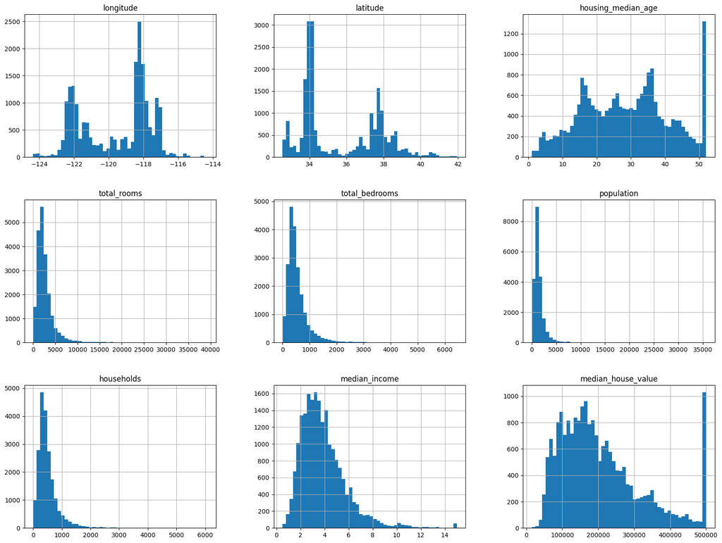

```python
%matplotlib inline
import matplotlib.pyplot as plt
housing.hist(bins=50, figsize=(20,15))
plt.show
```

## Sample a test set, put it aside, and never look at it (no data snooping!).

#### Random Sampling

```python
from sklearn.model_selection import train_test_split

train_set, test_set = train_test_split(housing, test_size=0.2, random_state=42)
```

#### Stratfield sampling

```python
import numpy as np
housing['income_cat'] = pd.cut(housing['median_income'],
                              bins = [0, 1.5, 3, 4.5, 6, np.inf],
                              labels = [1, 2, 3, 4, 5])
housing[['median_income','income_cat']]
```

|  | median_income | income_cat |
| --- | --- | --- |
| 0 | 8.3252 | 5 |
| 1 | 8.3014 | 5 |
| 2 | 7.2574 | 5 |
| 3 | 5.6431 | 4 |
| 4 | 3.8462 | 3 |
| ... | ... | ... |
| 20635 | 1.5603 | 2 |
| 20636 | 2.5568 | 2 |
| 20637 | 1.7000 | 2 |
| 20638 | 1.8672 | 2 |
| 20639 | 2.3886 | 2 |

20640 rows × 2 columns

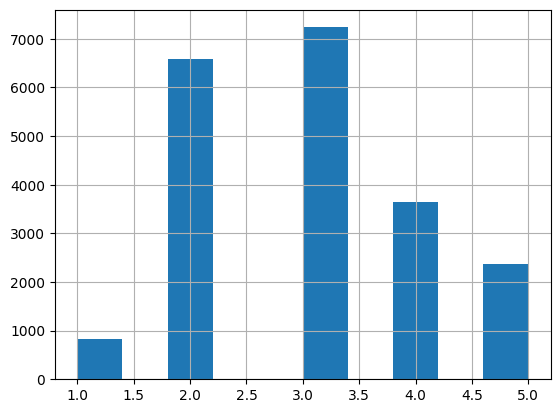

```python
import numpy as np
housing['income_cat'] = pd.cut(housing['median_income'],
                              bins = [0, 1.5, 3, 4.5, 6, np.inf],
                              labels = [1, 2, 3, 4, 5])
housing['income_cat'].hist()
plt.show()
```

```python
from sklearn.model_selection import StratifiedShuffleSplit
split = StratifiedShuffleSplit(n_splits=1, test_size=0.20, random_state=42)
for train_index, test_index in split.split(housing, housing['income_cat']):
    strat_train_set = housing.loc[train_index]
    strat_test_set = housing.loc[test_index]

print("Category proportion for overall dataset:\n", housing['income_cat'].value_counts() / len(housing))
print("Category proportion for stratified sampling:\n", strat_train_set['income_cat'].value_counts() / len(strat_train_set))
```

```
Category proportion for overall dataset:
 income_cat
3    0.350581
2    0.318847
4    0.176308
5    0.114438
1    0.039826
Name: count, dtype: float64
Category proportion for stratified sampling:
 income_cat
3    0.350594
2    0.318859
4    0.176296
5    0.114462
1    0.039789
Name: count, dtype: float64
```

```python
#for set_ in (strat_train_set, strat_test_set):
#    set_.drop("income_cat", axis=1, inplace=True)
```

# Explore the Data

## Create a copy of the data for exploration (sampling it down to a manageable size if necessary).

```python
housing = strat_train_set.copy()
```

## Study each attribute and its characteristics.

- Name
- Type (categorical, int/float, bounded/unbounded, text, structured, etc.)
- % of missing values
- Noisiness and type of noise (stochastic, outliers, rounding errors, etc.)
- Usefulness for the task
- Type of distribution (Gaussian, uniform, logarithmic, etc.)

```python
#READ ME > Dependences problem with Profile Report and pandas_profiling
#from pandas_profiling import ProfileReport
#profile = ProfileReport(housing, title="Pandas Profiling Report")
#profile.to_notebook_iframe()
```

## Visualize the data

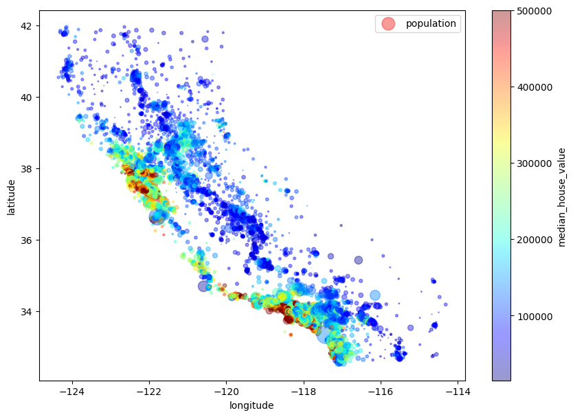

```python
housing.plot(kind="scatter", x="longitude", y="latitude", alpha=0.4,
             s=housing["population"]/100, label="population", figsize=(10,7),
             c="median_house_value", cmap=plt.cm.jet, colorbar=True)
plt.legend()
plt.show()
```

### Study the correlations between attributes.

```python
#corr column
corr_matrix = housing.select_dtypes(include=[float, int]).corr()
median_house_value_corr = corr_matrix["median_house_value"].sort_values(ascending=False)
print(median_house_value_corr)
```

```
median_house_value    1.000000
median_income         0.688075
total_rooms           0.134153
housing_median_age    0.105623
households            0.065843
total_bedrooms        0.049686
population           -0.024650
longitude            -0.045967
latitude             -0.144160
Name: median_house_value, dtype: float64
```

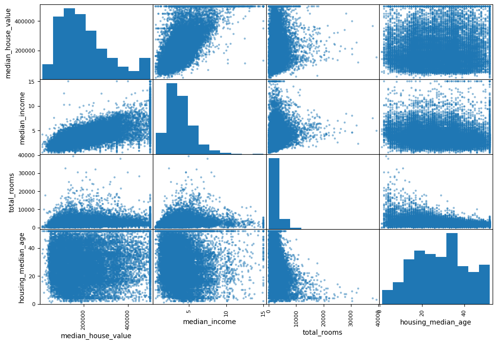

```python
from pandas.plotting import scatter_matrix

attributes = median_house_value_corr.index[0:4]
scatter_matrix(housing[attributes], figsize=(12, 8))
plt.show()
```

## Study how you would solve the problem manually.

## Identify the promising transformations you may want to apply.

```python
housing["rooms_per_household"] = housing["total_rooms"] / housing["households"]
housing["bedrooms_per_household"] = housing["total_bedrooms"] / housing["total_rooms"]
housing["populations_per_household"] = housing["population"] / housing["households"]

corr_matrix = housing.select_dtypes(include=['float64', 'int64']).corr()
corr_matrix["median_house_value"].sort_values(ascending=False)
```

```
median_house_value           1.000000
median_income                0.688075
rooms_per_household          0.151948
total_rooms                  0.134153
housing_median_age           0.105623
households                   0.065843
total_bedrooms               0.049686
populations_per_household   -0.023737
population                  -0.024650
longitude                   -0.045967
latitude                    -0.144160
bedrooms_per_household      -0.255880
Name: median_house_value, dtype: float64
```

## Identify extra data that would be useful.

## Document what you have learned.

# Prepare the Data

- Work on copies of the data (keep the original dataset intact).
- Write functions for all data transformations you apply.
  - So you can easily prepare the data the next time you get a fresh dataset
  - So you can apply these transformations in future projects
  - To clean and prepare the test set
  - To clean and prepare new data instances once your solution is live
  - To make it easy to treat your preparation choices as hyperparameters

## Data cleaning.

- Fix or remove outliers (optional)
- Fill in missing values (e.g., with zeros, mean, median...) or drop their rows (or columns)

```python
housing = strat_train_set.drop ("median_house_value", axis=1)
housing_labels = strat_train_set["median_house_value"].copy()
```

```python
#prepare data for missing data with the median of the column
#calculate median of each column
from sklearn.impute import SimpleImputer

imputer = SimpleImputer(strategy = "median")
housing_num = housing.drop("ocean_proximity", axis=1)
imputer.fit(housing_num)
print(imputer.statistics_)
```

```
[-118.51      34.26      29.      2119.       433.      1164.
  408.         3.54155]
```

## Feature selection (optional).

- Drop the attributes that provide no useful information for the task
- Use some dimensionality reduction technique if necessary (PCA, KernelPCA, LLE...)

## Feature engineering, where appropriate.

- Discretize continuous features
- Decompose features (e.g., categorical, date/time, etc.)
- Add promising transformations of features (e.g., log(x), sqrt(x), x^2, etc.)
- Aggregate features into promising new features

#### Handling Text and Categorical Attributes (added after processing 4.3)

```python
#manipulate columns for manage categorical var (like string)
housing_cat = housing[['ocean_proximity']].reset_index()
housing_cat.head()
```

|  | index | ocean_proximity |
| --- | --- | --- |
| 0 | 12655 | INLAND |
| 1 | 15502 | NEAR OCEAN |
| 2 | 2908 | INLAND |
| 3 | 14053 | NEAR OCEAN |
| 4 | 20496 | <1H OCEAN |

```python
#convert column in a float
from sklearn.preprocessing import OneHotEncoder

cat_encoder = OneHotEncoder()
housing_cat_1hot = cat_encoder.fit_transform(housing_cat)
print(housing_cat_1hot.toarray())
print(cat_encoder.categories_)
```

```
[[0. 0. 0. ... 0. 0. 0.]
 [0. 0. 0. ... 0. 0. 1.]
 [0. 0. 0. ... 0. 0. 0.]
 ...
 [0. 0. 0. ... 0. 0. 0.]
 [0. 0. 0. ... 0. 0. 0.]
 [0. 0. 0. ... 0. 0. 0.]]
[array([    0,     1,     2, ..., 20636, 20637, 20638], shape=(16512,)), array(['<1H OCEAN', 'INLAND', 'ISLAND', 'NEAR BAY', 'NEAR OCEAN'],
      dtype=object)]
```

### Aggregate features into promising new features (after 4.3)

```python
import numpy as np
from sklearn.base import BaseEstimator, TransformerMixin

class CombinedAttributeAdder(BaseEstimator, TransformerMixin):
    def __init__(self, add_bedrooms_per_room=True):
        self.add_bedrooms_per_room = add_bedrooms_per_room

    def fit(self, X, y=None):
        return self

    def transform(self, X):
        # Supponendo che X sia un array numpy o DataFrame
        rooms_ix = housing.columns.get_loc("total_rooms")
        bedrooms_ix = housing.columns.get_loc("total_bedrooms")
        population_ix = housing.columns.get_loc("population")
        households_ix = housing.columns.get_loc("households")

        rooms_per_household = X[:, rooms_ix] / X[:, households_ix]
        population_per_household = X[:, population_ix] / X[:, households_ix]
        if self.add_bedrooms_per_room:
            bedrooms_per_room = X[:, bedrooms_ix] / X[:, rooms_ix]
            return np.c_[X, rooms_per_household, population_per_household, bedrooms_per_room]
        else:
            return np.c_[X, rooms_per_household, population_per_household]

# Uso corretto
att_adder = CombinedAttributeAdder(add_bedrooms_per_room=False)
housing_extra_attribs = att_adder.transform(housing_num.values)
```

```python
housing_extra_attribs.shape
```

```
(16512, 10)
```

## Feauture scaling

- Standardize or normalize features

```python
#scale features > set the same order of magnitude of the values
from sklearn.preprocessing import StandardScaler #we take the min e max of each column and we divide each n of the column for the range
#keep attention to the ouliers
scaler = StandardScaler()
housing_extra_attribs_scaled = scaler.fit_transform(housing_extra_attribs)
housing_extra_attribs_scaled
```

```
array([[-0.94135046,  1.34743822,  0.02756357, ..., -0.8936472 ,
         0.01739526,  0.00622264],
       [ 1.17178212, -1.19243966, -1.72201763, ...,  1.292168  ,
         0.56925554, -0.04081077],
       [ 0.26758118, -0.1259716 ,  1.22045984, ..., -0.52543365,
        -0.01802432, -0.07537122],
       ...,
       [-1.5707942 ,  1.31001828,  1.53856552, ..., -0.36547546,
        -0.5092404 , -0.03743619],
       [-1.56080303,  1.2492109 , -1.1653327 , ...,  0.16826095,
         0.32814891, -0.05915604],
       [-1.28105026,  2.02567448, -0.13148926, ..., -0.390569  ,
         0.01407228,  0.00657083]], shape=(16512, 10))
```

#### Reconstruct data

- use pipelines to automate all steps if possible

```python
from sklearn.pipeline import Pipeline
from sklearn.compose import ColumnTransformer

#merge vars num and cat

num_attribs = housing_num.columns.tolist()
cat_attribs = ["ocean_proximity"]

num_pipeline = Pipeline([
    ('imputer', SimpleImputer(strategy='median')),
    ('attribs_adder', CombinedAttributeAdder()),
    ('std_scaler', StandardScaler())
])

full_pipeline = ColumnTransformer([
    ('num', num_pipeline, num_attribs),
    ('cat', OneHotEncoder(), cat_attribs)
])

housing_prepared = full_pipeline.fit_transform(housing)
housing_prepared
```

```
array([[-0.94135046,  1.34743822,  0.02756357, ...,  0.        ,
         0.        ,  0.        ],
       [ 1.17178212, -1.19243966, -1.72201763, ...,  0.        ,
         0.        ,  1.        ],
       [ 0.26758118, -0.1259716 ,  1.22045984, ...,  0.        ,
         0.        ,  0.        ],
       ...,
       [-1.5707942 ,  1.31001828,  1.53856552, ...,  0.        ,
         0.        ,  0.        ],
       [-1.56080303,  1.2492109 , -1.1653327 , ...,  0.        ,
         0.        ,  0.        ],
       [-1.28105026,  2.02567448, -0.13148926, ...,  0.        ,
         0.        ,  0.        ]], shape=(16512, 16))
```